# Tugas Praktikum STA 582 Sesi UTS

Maulida Fajrining Tyas (G1501202041)

4/17/2021

## Metodologi Pemodelan

Tujuan dari pemodelan ini ialah untuk memprediksi harga untuk listing rumah baru kepada pemilik rumah yang akan menjual properti mereka di situs *AirBNB*. Hasil prediksi ini kemudian akan menjadi rekomendasi harga kepada pemilik rumah agar tetap kompetitif bahkan sebelum mereka memiliki ulasan mengenai properti mereka.

Untuk menjawab tujuan di atas, maka pemodelan SML *(Statistical Machine Learning)* yang digunakan ialah *Random Forest*. Metode ini merupakan salah satu model yang *powerful* dalam memprediksi respon dengan tipe numerik maupun kategorik. *Random Forest* merupakan metode *ensemble* dimana konsep yang digunakan yaitu menggabungkan/agregasi hasil prediksi dari banyak pohon keputusan *(Decision tree)* untuk meningkatkan performa dari hasil prediksi. Keunggulan *Random Forest* dibandingkan dengan metode *ensemble* lainnya yaitu sifatnya dalam membentuk pohon-pohon keputusan *(Decision tree)* akan memiliki variabel-variabel yang berbeda yang diambil secara acak. Hal ini kemudian yang akan membuat tiap pohon keputusan yang terbentuk tidak memiliki korelasi antar pohon dan dapat mereduksi varians.

Penelitian ini menggunakan *package* dan ekosistem *mlr3* pada R sebagai mesin untuk melakukan pemodelan SML. Pemrograman dengan *mlr3* bersifat efisien, *object-oriented*, *extensible framework* untuk klasifikasi, regresi, analisis survival, dan metode pembelajaran mesin statistika lainnya dengan bahasa R. Pada ekosistem *mlr3* dapat dilakukan penggabungan model serta menyetel parameter pada model *(hyperparameter tuning, feature selection, and ensemble construction)* dengan mudah untuk memperoleh hasil komparasi.

Tahapan pemodelan yang akan dilakukan yaitu :  
1. Eksplorasi data  
2. Pra-pemrosesan data  
3. *Import* data ke dalam *mlr3*  
4. *Tuning hyperparameter*  
5. Komparasi model sebelum dan setelah *tuning*

### 1. Eksplorasi Data

Mengenal data lebih jauh sangat penting sebelum masuk ke langkah pemodelan. Pada tahap eksplorasi data dapat diketahui sifat, karakter serta sebaran data yang akan digunakan juga dapat mendeteksi adanya pencilan atau *outlier* serta nilai *NA* pada data dengan jumlah yang sangat besar.

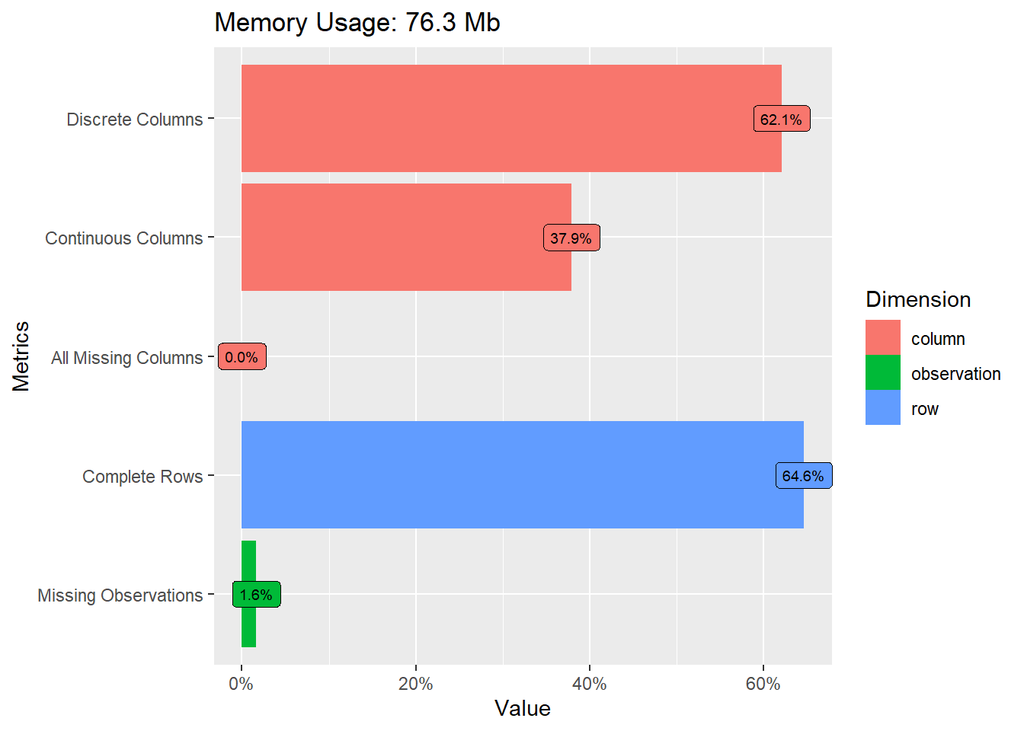

```r
plot_intro(data = data_house, geom_label_args = list(size=2.5))
```

Plot di atas menunjukkan bahwa data terdiri dari 62.1% variabel diskrit dan 37.9% variabel kontinu, serta memiliki 1.6% observasi yang hilang dari data keseluruhan. Namun, ternyata hanya terdapat 64.6% observasi lengkap yang tidak memiliki *missing values*.

Data yang digunakan merupakan data *house price* yang terdiri dari 51879 observasi dengan 29 kolom yang terdiri dari 17 variabel bertipe faktor, 1 variabel bertipe logical *(TRUE/FALSE)* dan 11 variabel bertipe numerik.

```r
skim_without_charts(data = data_house)
```

Data summary

| Name | data_house |
| --- | --- |
| Number of rows | 51879 |
| Number of columns | 29 |
| _______________________ |  |
| Column type frequency: |  |
| factor | 17 |
| logical | 1 |
| numeric | 11 |
| ________________________ |  |
| Group variables | None |

**Variable type: factor**

| skim_variable | n_missing | complete_rate | ordered | n_unique | top_counts |
| --- | --- | --- | --- | --- | --- |
| property_type | 0 | 1 | FALSE | 35 | Apa: 34370, Hou: 11502, Con: 1872, Tow: 1155 |
| room_type | 0 | 1 | FALSE | 3 | Ent: 28966, Pri: 21423, Sha: 1490 |
| amenities | 0 | 1 | FALSE | 47806 | {}: 428, {“t: 96, {”F: 65, {"P: 21 |
| bed_type | 0 | 1 | FALSE | 5 | Rea: 50391, Fut: 549, Pul: 419, Air: 326 |
| cancellation_policy | 0 | 1 | FALSE | 5 | str: 22720, fle: 15741, mod: 13333, sup: 74 |
| city | 0 | 1 | FALSE | 6 | NYC: 22655, LA: 15733, SF: 4539, DC: 3947 |
| description | 0 | 1 | FALSE | 51536 | Hel: 6, #NA: 5, Out: 5, Wel: 5 |
| first_review | 0 | 1 | FALSE | 2433 | emp: 11014, 1/1: 198, 1/2: 174, 1/2: 152 |
| host_has_profile_pic | 0 | 1 | FALSE | 3 | t: 51592, f: 159, emp: 128 |
| host_identity_verified | 0 | 1 | FALSE | 3 | t: 34838, f: 16913, emp: 128 |
| host_since | 0 | 1 | FALSE | 3026 | 3/3: 156, emp: 128, 2/1: 111, 5/1: 66 |
| instant_bookable | 0 | 1 | FALSE | 2 | f: 38325, t: 13554 |
| last_review | 0 | 1 | FALSE | 1260 | emp: 10989, 4/3: 929, 9/2: 872, 9/1: 826 |
| name | 0 | 1 | FALSE | 51486 | #NA: 8, Bun: 6, Spa: 5, Spa: 5 |
| neighbourhood | 0 | 1 | FALSE | 600 | emp: 4774, Wil: 2053, Bed: 1505, Bus: 1112 |
| thumbnail_url | 0 | 1 | FALSE | 46110 | emp: 5765, htt: 2, htt: 2, htt: 2 |
| zipcode | 0 | 1 | FALSE | 639 | 112: 1172, 902: 895, 112: 834, 941: 696 |

**Variable type: logical**

| skim_variable | n_missing | complete_rate | mean | count |
| --- | --- | --- | --- | --- |
| cleaning_fee | 0 | 1 | 0.74 | TRU: 38144, FAL: 13735 |

**Variable type: numeric**

| skim_variable | n_missing | complete_rate | mean | sd | p0 | p25 | p50 | p75 | p100 |
| --- | --- | --- | --- | --- | --- | --- | --- | --- | --- |
| id | 0 | 1.00 | 11288025.09 | 6083035.75 | 941.00 | 6297405.00 | 12282255.00 | 16405802.50 | 21228356.00 |
| accommodates | 0 | 1.00 | 3.15 | 2.16 | 1.00 | 2.00 | 2.00 | 4.00 | 16.00 |
| bathrooms | 144 | 1.00 | 1.23 | 0.58 | 0.00 | 1.00 | 1.00 | 1.00 | 8.00 |
| host_response_rate | 12754 | 0.75 | 0.94 | 0.16 | 0.00 | 1.00 | 1.00 | 1.00 | 1.00 |
| latitude | 0 | 1.00 | 38.44 | 3.08 | 33.34 | 34.12 | 40.66 | 40.75 | 42.39 |
| longitude | 0 | 1.00 | -92.43 | 21.72 | -122.51 | -118.34 | -77.00 | -73.95 | -70.99 |
| number_of_reviews | 0 | 1.00 | 20.82 | 37.49 | 0.00 | 1.00 | 6.00 | 23.00 | 605.00 |
| review_scores_rating | 11621 | 0.78 | 94.08 | 7.82 | 20.00 | 92.00 | 96.00 | 100.00 | 100.00 |
| bedrooms | 66 | 1.00 | 1.26 | 0.85 | 0.00 | 1.00 | 1.00 | 1.00 | 10.00 |
| beds | 84 | 1.00 | 1.71 | 1.25 | 0.00 | 1.00 | 1.00 | 2.00 | 18.00 |
| price | 0 | 1.00 | 160.37 | 168.93 | 1.00 | 75.00 | 111.00 | 185.00 | 1999.00 |

Berdasarkan tabel di atas, *missing values* hanya terdapat pada variabel bertipe numerik dan paling banyak ada pada variabel `host_response_rate` dan `review_scores_rating`

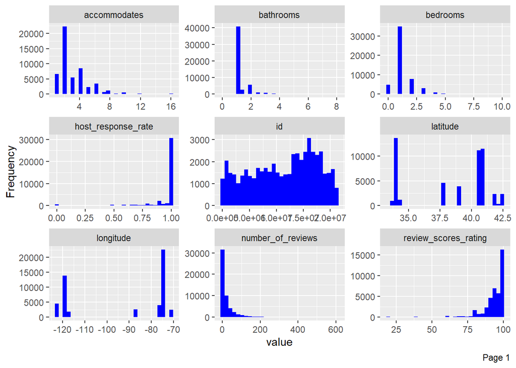

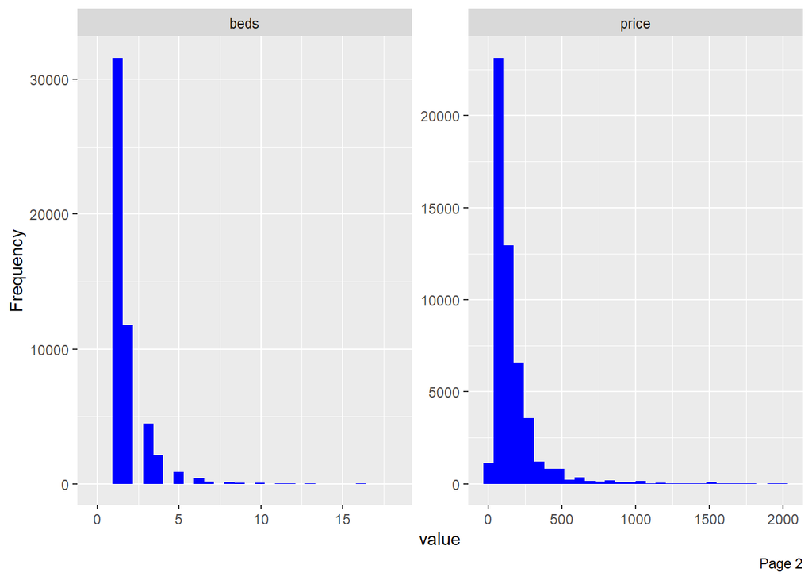

```r
plot_histogram(data=data_house,nrow=3, ncol=3,
               geom_histogram_args = list(fill="blue"))
```

Berdasarkan histogram yang ditampilkan pada variabel `price` atau harga dari properti di *AirBNB*, menunjukkan bahwa sebaran harga tidak menyebar secara normal dimana data menjulur ke kanan dan terdapat beberapa amatan yang memiliki harga yang jauh menyimpang dari rata-rata yang bernilai 160.3 satuan dan menjadi pencilan. Harga yang sangat tinggi ini mungkin dikarenakan terdapat beberapa properti yang memiliki fasilitas khusus atau mungkin berada pada lokasi strategis yang membuat harganya lebih mahal dari properti lain dengan fasilitas umum yang sama.

Hal menarik yang dapat dikatakan ialah pada situs *AirBNB* tingkat respon dari pemilik rumah sangat baik yang ditunjukkan oleh histogram pada variabel `host_response_rate` yang kebanyakan bernilai 100%. Begitu pula dengan variabel `review_scores_rating` atau ulasan pada situs ini kebanyakan memiliki skor yang sangat baik. Hal ini berarti bahwa pengguna situs *AirBNB* menyukai properti yang ditawarkan.

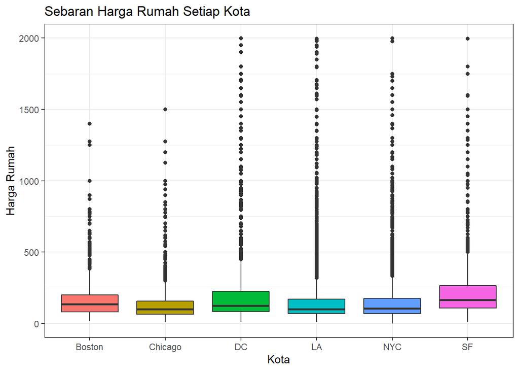

```r
data_house%>%
  filter(city %in% c("Boston","Chicago","DC","LA","NYC","SF"))%>%
  ggplot() +
  geom_boxplot(aes(x=city, y=price, fill=city), show.legend=F) +
  ggtitle("Sebaran Harga Rumah Setiap Kota") +
  ylab("Harga Rumah") +
  xlab("Kota") +
  theme(plot.title = element_text(hjust = 0.5))+
  theme_bw()
```

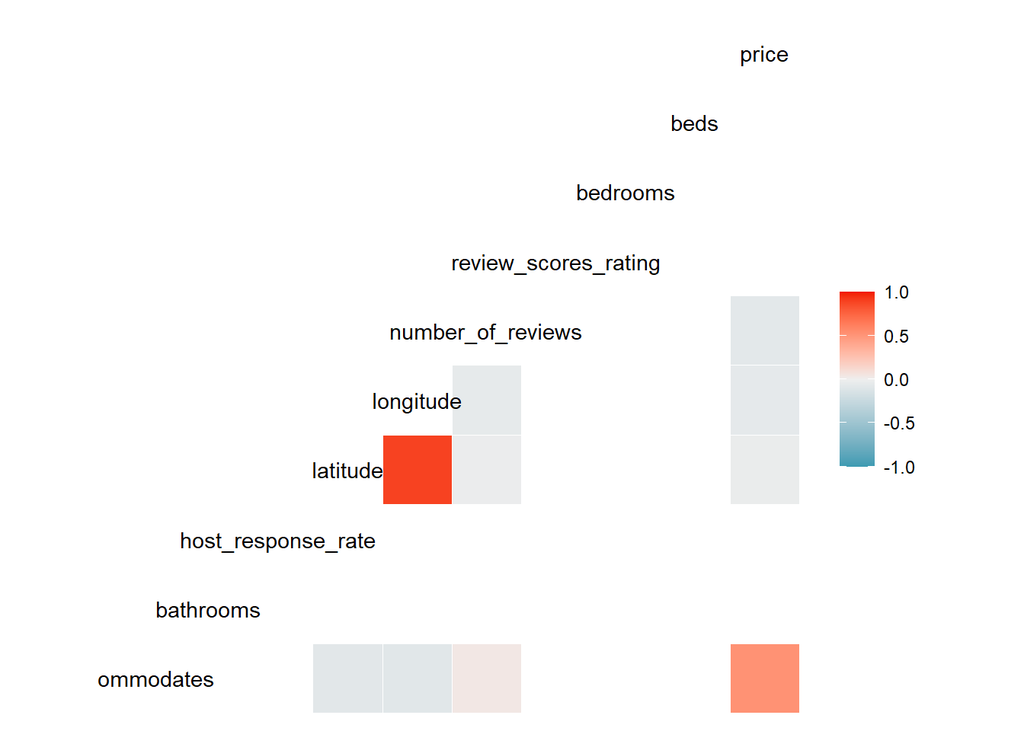

```r
ggcorr(data_house[,-1], method = c("everything","pearson"),geom = "tile")
```

Secara visual, dapat dilihat pada plot di atas bahwa korelasi yang terbentuk antara variabel prediktor terhadap harga hanya terdapat pada `number_of_reviews`, `longitude`, `latitude`, dan `accomodates`.

### 2. Pra-pemrosesan Data

Sebelum masuk ke tahap pemodelan, penting untuk melakukan pembersihan data agar data yang digunakan memiliki kualitas yang baik. Untuk tujuan prediksi respon bertipe numerik, maka variabel prediktor yang digunakan adalah semua yang bertipe numerik saja. `id` tidak digunakan karena hanya merupakan penanda untuk setiap unit properti sehingga tidak dipertimbangkan ke dalam model.

```r
data_house <- data_house %>%
  select(-id) %>%
  select_if(is.numeric) %>%
  na.omit()
```

### 3. *Import* Data ke dalam *mlr3*

Langkah awal dalam menggunakan ekosistem *mlr3* ialah dengan mendefinisikan `task` yang akan digunakan, karena dalam kasus ini kita akan memprediksi respon numerik, maka digunakan `TaskRegr`.

```r
task_house = TaskRegr$new(id="house", backend = data_house, target = "price")
```

Selanjutnya mendefinisikan model yang digunakan yaitu model *Random Forest* yang menggunakan `package` dari `ranger`.

```r
model_rf <- lrn("regr.ranger", importance="impurity")
```

### 4. *Tuning Hyperparameter*

Pada tahap ini, akan didefinisikan parameter apa saja yang akan dioptimisasi agar dapat menghasilkan ukuran kebaikan terbaik (ukuran yang digunakan yaitu MAE).

Berikut adalah pendefinisian hyperparameter.

```r
param_bound_rf <- ParamSet$new(params = list(ParamInt$new("mtry",
                                                          lower = 2,
                                                          upper = 8),
                                             ParamInt$new("max.depth",
                                                          lower = 1,
                                                          upper = 15)))
terminate = trm("evals", n_evals = 5) #stopping criteria
tuner <- tnr("random_search") #metode optimisasi
resample_inner = rsmp("cv", folds = 5)
```

Pada kasus ini, dipilih dua parameter yaitu `mtry` (banyaknya variabel yang terbentuk pada setiap pohon) dan `max.depth` (kedalaman pohon yang akan terbentuk).

`trm` = fungsi untuk kriteria penghentian dalam proses optimisasi  
`tnr` = fungsi untuk metode optimisasi yang digunakan  
`rsmp`= fungsi untuk melakukan *Cross-validation*.

Selanjutnya dibentuk fungsi `AutoTuner` dengan menggabungkan informasi dari sebelumnya.

```r
model_rf_tune <- AutoTuner$new(learner = model_rf,
                               measure = msr("regr.mae"),
                               terminator = terminate,
                               resampling = resample_inner,
                               search_space = param_bound_rf,
                               tuner = tuner,
                               store_models = TRUE)

resample_outer = rsmp("cv", folds = 5)
set.seed(1)
resample_outer$instantiate(task = task_house)
```

Perbedaan *resample inner* dan *outer* yaitu, pada *inner* digunakan untuk *cross-validation* untuk pembagian data dalam menentukan parameter terbaik dari rentang yang dipilih pada `param_bound_rf` kemudian setelah diperoleh maka akan dihitung performanya pada pembagian data dengan *resample outer*.

### 5. Komparasi Model Sebelum dan Sesudah Tuning

```r
model_house <- list(model_rf,
                    model_rf_tune)

design <- benchmark_grid(tasks = task_house,
                         learners = model_house,
                         resamplings = resample_outer)

lgr::get_logger("bbotk")$set_threshold("warn")
bmr = benchmark(design,store_models = TRUE)
```

[output not shown]

[output cut: 132 more lines]

[output not shown]

Hasil komparasi adalah sebagai berikut.

```r
result = bmr$aggregate(msr("regr.mae"))
result
```

```
##    nr      resample_result task_id        learner_id resampling_id iters
## 1:  1 <ResampleResult[21]>   house       regr.ranger            cv     5
## 2:  2 <ResampleResult[21]>   house regr.ranger.tuned            cv     5
##    regr.mae
## 1: 45.10324
## 2: 45.50214
```

Hasil yang diperoleh menunjukkan bahwa nilai MAE *(mean absolute error)* yang terendah ada pada model yang tidak di-tuned.

## Pembahasan Hasil Pemodelan

### 1. Parameter Terbaik

Fungsi berikut digunakan untuk mengambil nilai parameter terbaik yang akan digunakan untuk prediksi.

```r
get_param_res <- function(i){
  as.data.table(bmr)$learner[[i]]$tuning_result
}

best_rf_param =map_dfr(6:10,get_param_res)
best_rf_param
```

```
##    mtry max.depth learner_param_vals  x_domain regr.mae
## 1:    4        12          <list[4]> <list[2]> 46.08535
## 2:    3        14          <list[4]> <list[2]> 46.07318
## 3:    7        14          <list[4]> <list[2]> 45.45741
## 4:    8        14          <list[4]> <list[2]> 45.44567
## 5:    3        15          <list[4]> <list[2]> 45.76327
```

```r
best_rf_param %>% slice_min(regr.mae)
```

```
##    mtry max.depth learner_param_vals  x_domain regr.mae
## 1:    8        14          <list[4]> <list[2]> 45.44567
```

```r
best_rf_param_value <-  c(best_rf_param %>%
                            slice_min(regr.mae) %>%
                            pull(mtry),
                          best_rf_param %>%
                            slice_min(regr.mae) %>%
                            pull(max.depth))
best_rf_param_value
```

```
## [1]  8 14
```

### 2. Interpretasi Model

Dengan menggunakan nilai parameter terbaik, maka dibentuk model berdasarkan nilai parameter tersebut sebagai berikut.

```r
model_rf_best = lrn("regr.ranger", mtry=best_rf_param_value[1],
                    max.depth=best_rf_param_value[2], importance="impurity")
model_rf_best$train(task = task_house)
```

Selanjutnya dapat diperoleh variabel mana saja yang berpengaruh besar terhadap model *Random Forest* yang dibentuk.

```r
model_rf_best$model$variable.importance
```

```
##         accommodates            bathrooms             bedrooms
##             56102418            120443836            172772210
##                 beds   host_response_rate             latitude
##             10150056              9209808             72649326
##            longitude    number_of_reviews review_scores_rating
##             89100013             22182479             16438301
```

```r
importance <- data.frame(Predictors = names(model_rf_best$model$variable.importance),
                         impurity = model_rf_best$model$variable.importance)
rownames(importance) <- NULL
importance %>% arrange(desc(impurity))
```

```
##             Predictors  impurity
## 1             bedrooms 172772210
## 2            bathrooms 120443836
## 3            longitude  89100013
## 4             latitude  72649326
## 5         accommodates  56102418
## 6    number_of_reviews  22182479
## 7 review_scores_rating  16438301
## 8                 beds  10150056
## 9   host_response_rate   9209808
```

Dapat dilihat bahwa variabel `bedrooms` memiliki nilai *importance* tertinggi yang berarti `bedrooms` memiliki pengaruh yang besar dalam menentukan harga.

### 3. Prediksi

Data baru yang akan digunakan untuk memprediksi terdiri dari 22232 observasi. Sebelum dilakukan prediksi, dilakukan pra-pemrosesan pada data baru untuk mengatasi adanya *missing values* dan variabel bertipe selain numerik.

```r
data_house_baru <- data_house_baru %>%
  arrange(id) %>%
  select(-id) %>%
  select_if(is.numeric)
```

Dalam mengatasi adanya *missing values*, setiap baris dengan *missing values* akan diganti dengan nilai tengah (median) dari kolom dimana baris itu berada.

```r
data_house_baru[is.na(data_house_baru)] = 0
data_house_baru$bathrooms[data_house_baru$bathrooms==0] = median(data_house_baru$bathrooms)
data_house_baru$host_response_rate[data_house_baru$host_response_rate==0] = median(data_house_baru$host_response_rate)
data_house_baru$review_scores_rating[data_house_baru$review_scores_rating==0] = median(data_house_baru$review_scores_rating)
data_house_baru$bedrooms[data_house_baru$bedrooms==0] = median(data_house_baru$bedrooms)
data_house_baru$beds[data_house_baru$beds==0] = median(data_house_baru$beds)
```

Setelah data sudah siap, dilakukan prediksi dengan hasil prediksi dapat dilihat sebagai berikut.

```r
prediksi_rf_new <- model_rf_best$predict_newdata(newdata = data_house_baru)
as.data.table(prediksi_rf_new)
```

```
##        row_ids truth  response
##     1:       1    NA 204.06677
##     2:       2    NA 252.64807
##     3:       3    NA 245.79250
##     4:       4    NA 128.23840
##     5:       5    NA 101.27564
##    ---
## 22228:   22228    NA 123.70404
## 22229:   22229    NA 112.52940
## 22230:   22230    NA 112.61220
## 22231:   22231    NA  76.79138
## 22232:   22232    NA 210.47659
```